# Simple Linear Regression

```r
# Load your libraries
library(mosaic)
library(DT)
library(car)
library(tidyverse)
library(pander)

# Load your data after saving a csv file in your Data folder.
# You can use either
#   someName <- read.csv("../Data/YourDataFileName.csv", header=TRUE)
# or
#   library(readr)
#   someName <- read_csv("../Data/YourDataFileName.csv")

# Don't forget to run "Session -> Set Working Directory -> To Source file location"
```

## Background

I am interested in movies and their ability to generate revenue. Movie making, though an art, often involves massive business ventures and can be an easy way to lose millions of dollars in investments. Needless to say, being able to predict movie success before the investment is made is a very important, and useful, skill.

One of the main, assumptions up and coming film makers make is that in order for them to make good movies they need money. I’ll be testing that notion in this analysis.

## Question

We’ll model that question as follows:

$$\underbrace{Y_i}_\text{Revenue} = \beta_0 + \beta_1 \underbrace{X_i}_\text{Budget} + \epsilon_i \quad \text{where} \ \epsilon_i \sim N(0, \sigma^2)$$
Our null hypothesis is that the slope of the regression model,$\beta_1$ is equal to 0, or in other words that the Budget and Revenue are not related. OUr alternative hypothesis is that the slope is not equal to 0 and, therefore, that there is some sort of relationship between the two factors.
$$H_0: \beta_1 = 0$$
$$H_a: \beta_1 \neq 0$$
$$\alpha = 0.05$$

## Data

For this analysis we’ll use data collect by the The Movie Database. They’re data has been collected for download at on Kaggle.com as well, [click here for the link.](https://www.kaggle.com/tmdb/tmdb-movie-metadata)

### Show Data

```r
library(readr)
movies <- read_csv("../../Data/tmdb_5000_movies.csv")
```

The Kaggle website notes that budget values that equal zero should probably be treated as if they were null. I’ll filter them out of our dataframe and do the same for revenue values.

```r
movies2 <- movies %>%
  select(
    c(original_title, budget, revenue, release_date)
  ) %>%
  filter(
    budget != 0 & revenue != 0
  ) %>%
  droplevels()
```

```r
datatable(movies2)
```

|  | original_title | budget | revenue | release_date |
| --- | --- | --- | --- | --- |
| 1 | Avatar | 237000000 | 2787965087 | 2009-12-10 |
| 2 | Pirates of the Caribbean: At World's End | 300000000 | 961000000 | 2007-05-19 |
| 3 | Spectre | 245000000 | 880674609 | 2015-10-26 |
| 4 | The Dark Knight Rises | 250000000 | 1084939099 | 2012-07-16 |
| 5 | John Carter | 260000000 | 284139100 | 2012-03-07 |
| 6 | Spider-Man 3 | 258000000 | 890871626 | 2007-05-01 |
| 7 | Tangled | 260000000 | 591794936 | 2010-11-24 |
| 8 | Avengers: Age of Ultron | 280000000 | 1405403694 | 2015-04-22 |
| 9 | Harry Potter and the Half-Blood Prince | 250000000 | 933959197 | 2009-07-07 |
| 10 | Batman v Superman: Dawn of Justice | 250000000 | 873260194 | 2016-03-23 |

[output cut: 3219 more lines]

## Analysis

For this analysis, we’ll conduct test for linear regression, plot a scatterplot and a regression line, check assumptions and find the confidence intervals.

```r
movies2.lm <- lm(
  revenue ~ budget,
  data = movies2
)
```

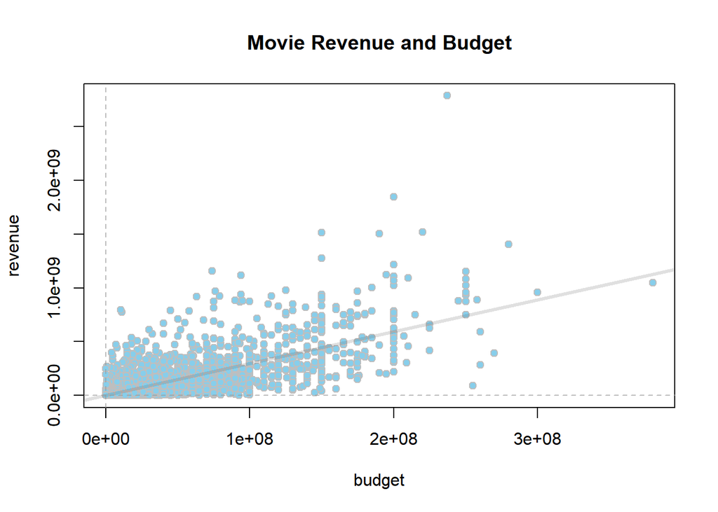

```r
plot(revenue ~ budget,
     data = movies2,
     pch = 21,
     bg = "skyblue",
     col = "gray",
     main = "Movie Revenue and Budget"
     )

abline(
  movies2.lm,
  lwd = 3,
  col = rgb(.4, .4, .4, .2)
)

abline(v=seq(40,120,20), h=seq(40,120,20), lty=2, col=rgb(.6,.6,.6,.2))
```

```r
movies2 %>%
  summarise(cor(budget, revenue, use = "complete.obs")) %>%
              pander( )
```

| cor(budget, revenue, use = “complete.obs”) |
| --- |
| 0.7054 |

Though the dots aren’t tightly clustered, there does seem to be a consistency in the slope. The correlation coefficient is 0.705, so there does seem to be a correlation.

The estimated slope is 2.96, which is significantly different from zero since $p=0 $ for this analysis. Below I have shown the complete summary of the regression.

```r
pander(summary(movies2.lm))
```

|  | Estimate | Std. Error | t value | Pr(>\|t\|) |
| --- | --- | --- | --- | --- |
| **(Intercept)** | 902541 | 3151720 | 0.2864 | 0.7746 |
| **budget** | 2.96 | 0.05236 | 56.53 | 0 |

Fitting linear model: revenue ~ budget

| Observations | Residual Std. Error | $R^2$ | Adjusted $R^2$ |
| --- | --- | --- | --- |
| 3229 | 132073814 | 0.4976 | 0.4974 |

The mathematical equation for the scatterplot above is

$$\underbrace{\hat{Y}_i}_\text{Mean Revenue} = 902541 + 2.96 \underbrace{X_i}_\text{Budget}$$
Since our p-value is less than our alpha we can assume that we have sufficient evidence to reject the null hypothesis. First, however let’s check the linear regression assumptions.

## Appropriateness of the Regression

The Regression fails two assumptions. The resideuals in the Q-Q plot are not normal, though the Residuals vs Fitted plot shows that the data is essentially linear. The Residuals vs. Order plot shows that there the error terms seem to be correlated due to the obvious megaphone shape we see there.

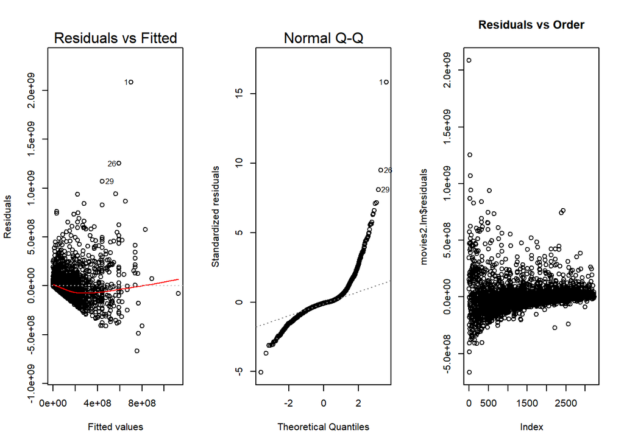

```r
par(mfrow = c(1,3))
plot(movies2.lm, which = 1:2)
plot(movies2.lm$residuals, main = "Residuals vs Order")
```

When checking the confidence intervals below, we see that the intercept varies greatly. Revenue could be anywhere between 5.3 million in the negative to 7.1 milliion in the positive.

```r
confint(movies2.lm, level = .95) %>% pander()
```

|  | 2.5 % | 97.5 % |
| --- | --- | --- |
| **(Intercept)** | -5277035 | 7082117 |
| **budget** | 2.857 | 3.063 |

## Conclusion

More research should be done into the way the data was gathered and perhaps this test should be conducted with inflation accounted for since the data points span from 1916 to 2017. As it stands, since we haven’t met the assumptions for the analysis, we can’t conclude that the more money you put into a movie production the more revenue you’ll earn. However, further examination might yield more useful results.